# R script data analysis and figures

Heritability of immunity traits and resistance of Atlantic salmon against the sea louse Caligus rogercresseyi

Dr. José A. Gallardo and Débora Torrealba.

Pontificia Universidad Católica de Valparaíso.  
jose.gallardo@pucv.cl

15 July 2023

## Introducction

Extensive research has been conducted on the immune response of Atlantic salmon to sea lice, yet the mechanisms underlying resistance in some fish and susceptibility in others remain unclear. This study aimed to assess the heritability of three key proteins associated with innate immunity and resistance in Salmo salar against the sea louse Caligus rogercresseyi. Specifically, the abundance of two pro-inflammatory cytokines, Tnfα and Il-8, along with an antioxidant enzyme, Nkef, was quantified in the skin and gill tissue of 21 families and 268 individuals using indirect ELISA. The study encompassed a wide range of parasite loads, ranging from low or resistant to high or susceptible.

#### Experimental desing

In this study, the researchers measured the abundances of three immune-related proteins (Nkef, Tnfα, and Il-8) in undamaged skin and gill tissues of Atlantic salmon. The samples were mechanically homogenized in lysis buffer and centrifuged, and the resulting supernatants were stored for further analysis. Total protein quantification was performed, and the samples were diluted and seeded in a Maxisorp plate. After overnight incubation and blocking, the plates were incubated with primary and secondary antibodies. The chromagen substrate TMB was added, and the reaction was stopped and measured at 450 nm. The production and validation of the antibodies were carried out based on previous studies.

The heritable variation of the traits was estimated using a linear mixed model, considering fixed effects and covariables such as tank, body weight, and sessile lice. The magnitude of estimated heritability was classified as low, moderate, high, or very high based on predetermined thresholds. Statistical analysis included non-parametric tests and Pearson’s correlation to assess the association between immunity traits and resistance traits. Familiar phenotypic correlation coefficients were also calculated.

The software used for statistical analysis were GraphPad Prism 8.0 and R.

#### Import and delete outliers

```
##      Animal         Sire          Dam          Family         Pit      Tank
##  3000008:  1   23061  : 39   117058 : 14   1      : 14   22     :  1   1:145
##  3000012:  1   23042  : 36   117183 : 14   28     : 14   23     :  1   2:123
##  3000017:  1   23052  : 26   117201 : 14   30     : 14   28     :  1
##  3000035:  1   23069  : 26   117211 : 14   32     : 14   29     :  1
##  3000037:  1   23033  : 14   2057111: 14   73     : 14   33     :  1
##  3000038:  1   23057  : 14   117110 : 13   7      : 13   34     :  1
##  (Other):262   (Other):113   (Other):185   (Other):185   (Other):262
##          Group    Body_Lenght_cm  Body_weight_grams  Sessile_lice
##  Medium     :94   Min.   :18.00   Min.   : 60.0     Min.   :  1.00
##  Resistant  :90   1st Qu.:21.50   1st Qu.:102.0     1st Qu.: 17.00
##  Susceptible:84   Median :23.00   Median :129.0     Median : 24.00
##                   Mean   :23.18   Mean   :131.9     Mean   : 29.41
##                   3rd Qu.:25.00   3rd Qu.:157.0     3rd Qu.: 39.00
##                   Max.   :33.00   Max.   :321.0     Max.   :107.00
##
##     IL8gill0        TNFgill0       NKEFgill0        IL8skin0
##  Min.   :130.0   Min.   : 20.4   Min.   :0.700   Min.   : 57.2
##  1st Qu.:288.5   1st Qu.:107.4   1st Qu.:2.145   1st Qu.:305.1
##  Median :328.9   Median :158.3   Median :2.790   Median :389.2
##  Mean   :332.3   Mean   :174.3   Mean   :2.869   Mean   :383.8
##  3rd Qu.:377.3   3rd Qu.:226.6   3rd Qu.:3.610   3rd Qu.:463.4
##  Max.   :582.9   Max.   :470.9   Max.   :5.790   Max.   :647.2
##  NA's   :30      NA's   :39      NA's   :37      NA's   :55
##     TNFskin0       NKEFskin0
##  Min.   :  5.2   Min.   : 1.360
##  1st Qu.:157.0   1st Qu.: 4.080
##  Median :234.4   Median : 5.680
##  Mean   :221.6   Mean   : 6.223
##  3rd Qu.:273.1   3rd Qu.: 8.130
##  Max.   :458.3   Max.   :12.780
##  NA's   :41      NA's   :39
```

## Exploratory data analysis: Sea lice boxplot

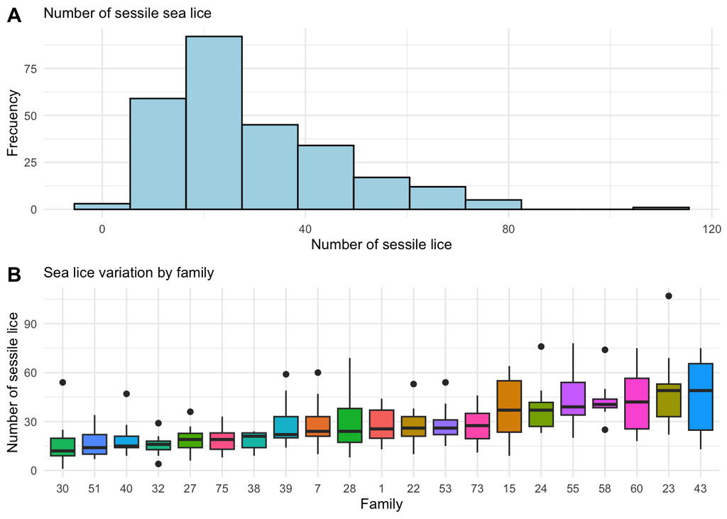

## Exploratory data analysis: Immunity traits

### Histograms

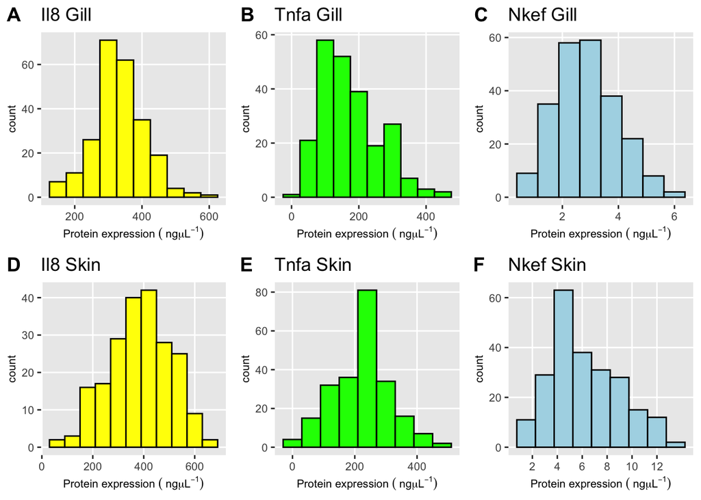

### Boxplots

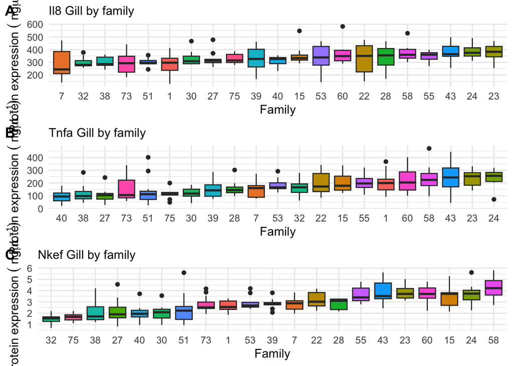

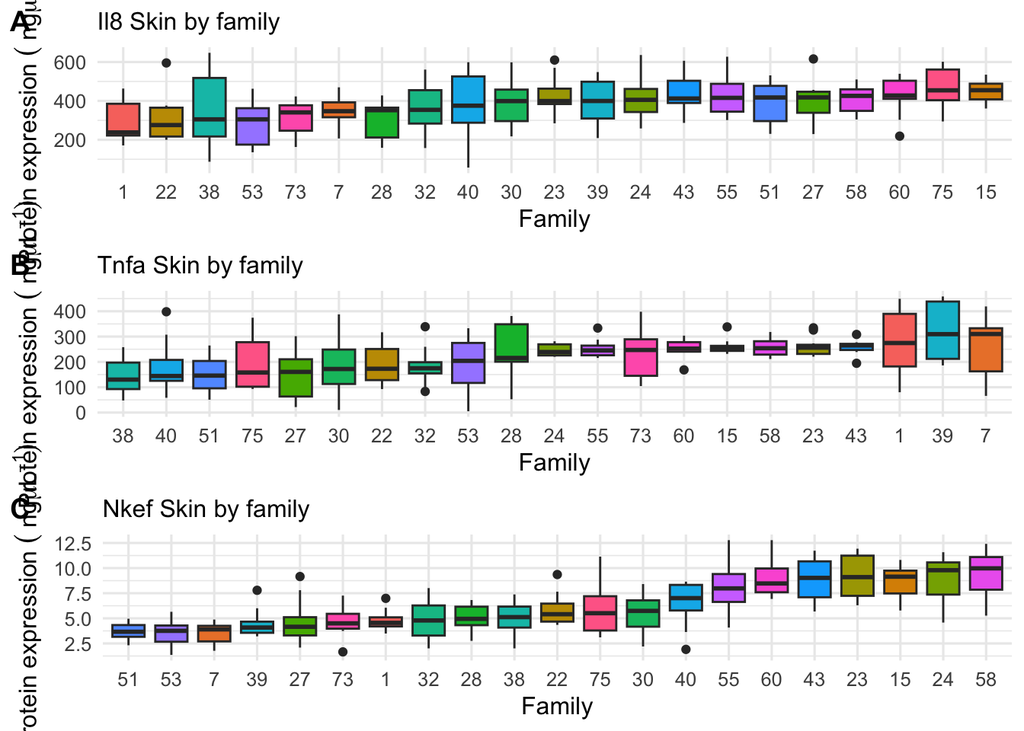

```
## [1] "/Users/josegallardomatus/Dropbox/PAPERS/1_Caligus_inmunidad/Immunity_caligus/R_script&data"
```

## Phenotypic correlations between sea lice and immunity traits: individual levels.

```
## # A tibble: 6 × 7
##   Sessile_lice IL8gill0 TNFgill0 NKEFgill0 IL8skin0 TNFskin0 NKEFskin0
##          <dbl>    <dbl>    <dbl>     <dbl>    <dbl>    <dbl>     <dbl>
## 1           44     236.     150.      2.44      NA       NA       6.05
## 2           43     312.     133.      3.14      NA      398.      5.46
## 3           42     278.     209.      3.3      463.     449.      3.6
## 4           38     202.     190.      2.13     209.     157.      3.49
## 5           34     130      108.      2.68      NA       NA       4.39
## 6           32     297      368.      2.55     331.     182.      4.55
```

```
##              Sessile_lice IL8gill0 TNFgill0 NKEFgill0 IL8skin0 TNFskin0
## Sessile_lice         1.00     0.32     0.40      0.40     0.05     0.30
## IL8gill0             0.32     1.00     0.53      0.31     0.12     0.14
## TNFgill0             0.40     0.53     1.00      0.38    -0.03     0.25
## NKEFgill0            0.40     0.31     0.38      1.00     0.04     0.35
## IL8skin0             0.05     0.12    -0.03      0.04     1.00     0.47
## TNFskin0             0.30     0.14     0.25      0.35     0.47     1.00
## NKEFskin0            0.39     0.47     0.41      0.42     0.29     0.27
##              NKEFskin0
## Sessile_lice      0.39
## IL8gill0          0.47
## TNFgill0          0.41
## NKEFgill0         0.42
## IL8skin0          0.29
## TNFskin0          0.27
## NKEFskin0         1.00
```

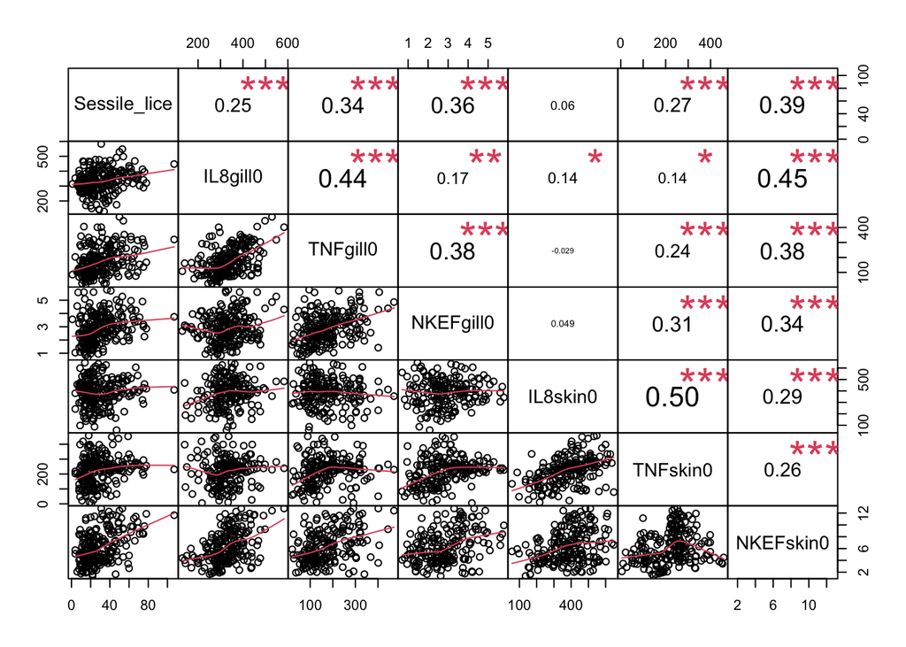

## Phenotypic correlations between sea lice and immunity traits: familiar levels.

```
##              Sessile lice IL8 gill TNF gill NKEF gill IL8 skin TNF skin
## Sessile lice         1.00     0.72     0.80      0.85     0.44     0.66
## IL8 gill             0.72     1.00     0.65      0.72     0.63     0.20
## TNF gill             0.80     0.65     1.00      0.85     0.26     0.50
## NKEF gill            0.85     0.72     0.85      1.00     0.33     0.46
## IL8 skin             0.44     0.63     0.26      0.33     1.00     0.03
## TNF skin             0.66     0.20     0.50      0.46     0.03     1.00
## NKEF skin            0.58     0.74     0.58      0.56     0.64     0.15
##              NKEF skin
## Sessile lice      0.58
## IL8 gill          0.74
## TNF gill          0.58
## NKEF gill         0.56
## IL8 skin          0.64
## TNF skin          0.15
## NKEF skin         1.00
```

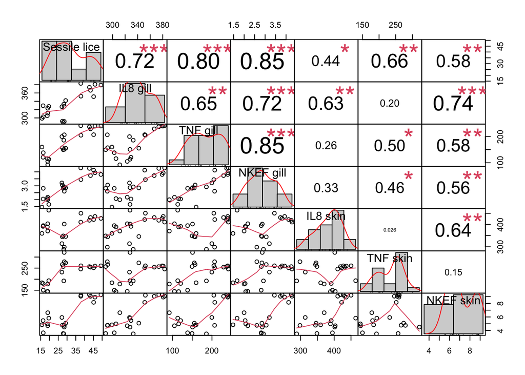

## Lineal model: Ancova

### Sea lice

```
## Analysis of Variance Table
##
## Response: cal_im$Sessile_lice
##                           Df Sum Sq Mean Sq F value    Pr(>F)
## cal_im$Tank                1    637  637.32  3.4987   0.06261 .
## cal_im$Family             20  29918 1495.92  8.2122 < 2.2e-16 ***
## cal_im$Body_weight_grams   1   3045 3044.53 16.7137 5.897e-05 ***
## Residuals                245  44629  182.16
## ---
## Signif. codes:  0 '***' 0.001 '**' 0.01 '*' 0.05 '.' 0.1 ' ' 1
```

### IL8 Gills

```
## Analysis of Variance Table
##
## Response: cal_im$IL8gill0
##                           Df  Sum Sq Mean Sq F value   Pr(>F)
## cal_im$Group               2  168144   84072 16.4979 2.17e-07 ***
## cal_im$Tank                1   18526   18526  3.6356   0.0579 .
## cal_im$Family             18   59933    3330  0.6534   0.8538
## cal_im$Sessile_lice        1    6936    6936  1.3611   0.2446
## cal_im$Body_weight_grams   1      12      12  0.0024   0.9613
## Residuals                214 1090524    5096
## ---
## Signif. codes:  0 '***' 0.001 '**' 0.01 '*' 0.05 '.' 0.1 ' ' 1
```

```
## Analysis of Variance Table
##
## Response: IL8_Gills$IL8gill0
##                                 Df Sum Sq Mean Sq F value    Pr(>F)
## IL8_Gills$Group                  1 122434  122434 41.6326 1.318e-09 ***
## IL8_Gills$Tank                   1     93      93  0.0316    0.8591
## IL8_Gills$Group:IL8_Gills$Tank   1    873     873  0.2968    0.5867
## Residuals                      156 458769    2941
## ---
## Signif. codes:  0 '***' 0.001 '**' 0.01 '*' 0.05 '.' 0.1 ' ' 1
```

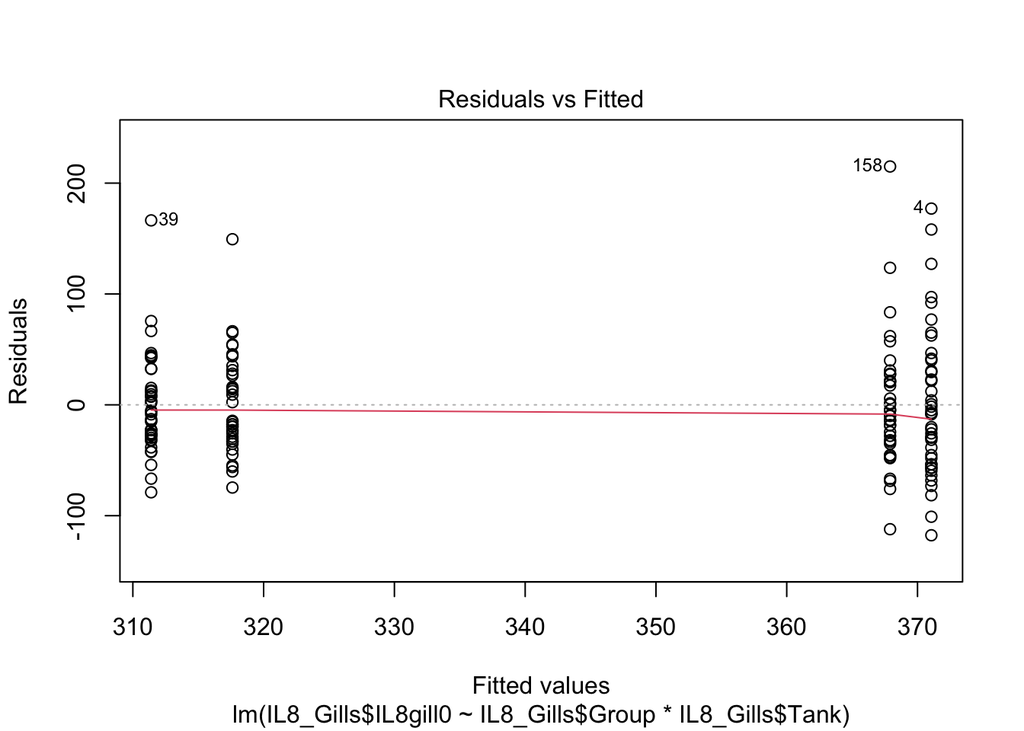

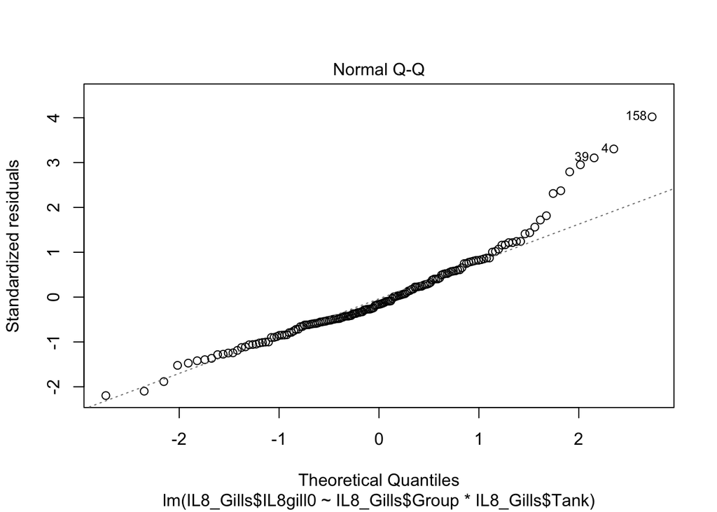

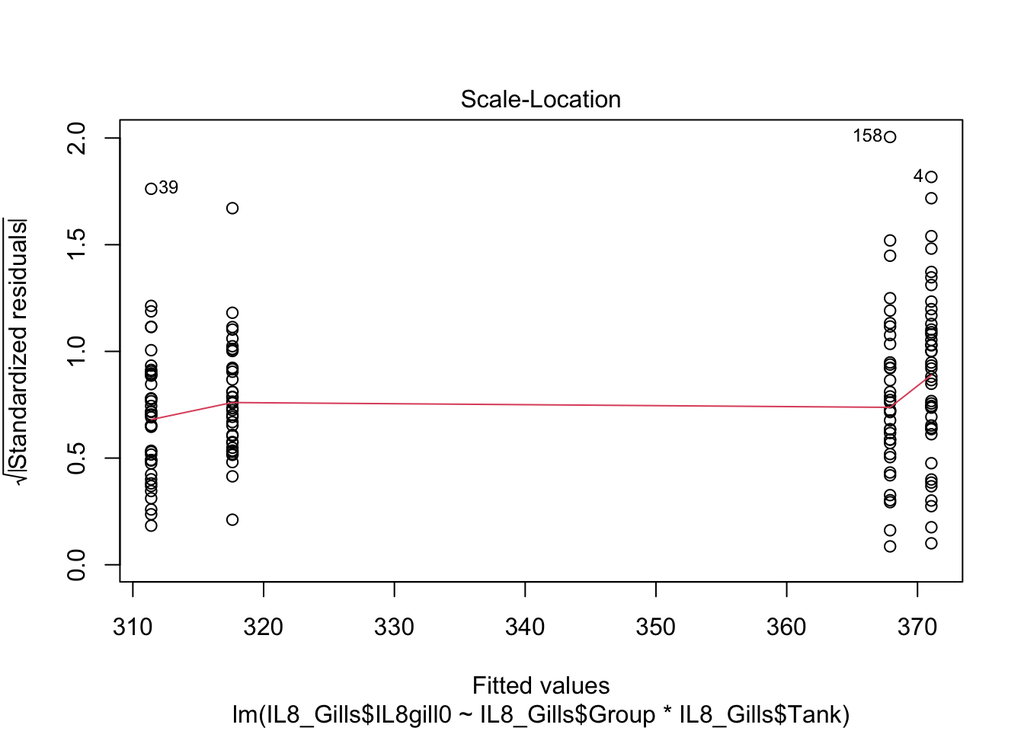

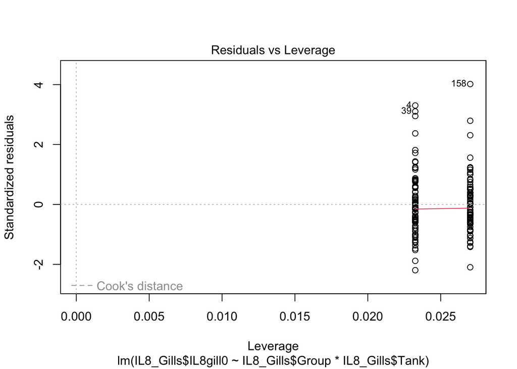

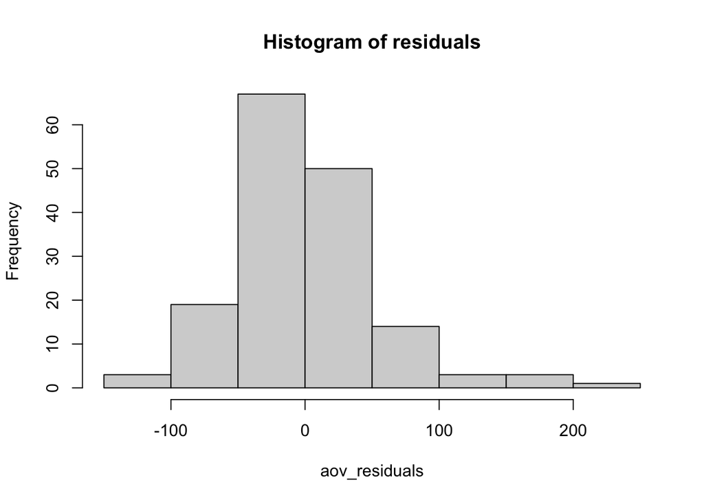

```
##
##  Shapiro-Wilk normality test
##
## data:  aov_residuals
## W = 0.93773, p-value = 1.822e-06
```

```
##
##   Welch's Heteroscedastic F Test (alpha = 0.05)
## -------------------------------------------------------------
##   data : IL8gill0 and Group
##
##   statistic  : 42.07772
##   num df     : 1
##   denom df   : 141.7501
##   p.value    : 1.364619e-09
##
##   Result     : Difference is statistically significant.
## -------------------------------------------------------------
```

```
##
##  Kruskal-Wallis rank sum test
##
## data:  IL8gill0 by Group
## Kruskal-Wallis chi-squared = 39.343, df = 1, p-value = 3.555e-10
```

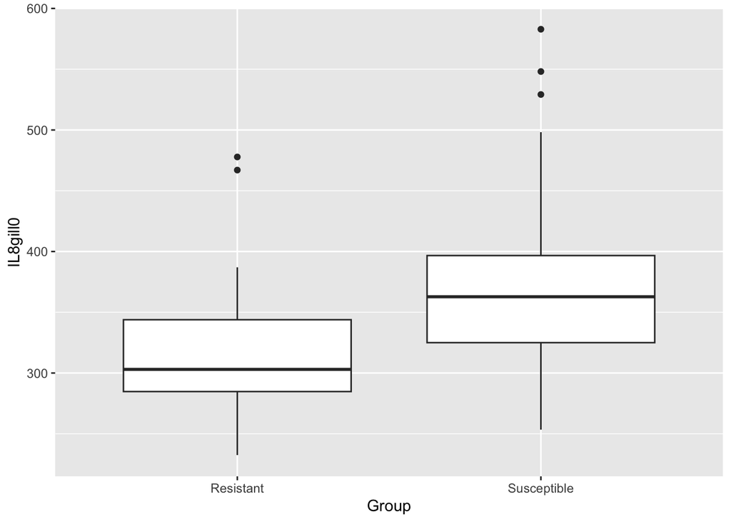

```
##   Tukey multiple comparisons of means
##     95% family-wise confidence level
##
## Fit: aov(formula = IL8gill0 ~ Group, data = IL8_Gills)
##
## $Group
##                         diff      lwr      upr p adj
## Susceptible-Resistant 55.325 38.47955 72.17045     0
```

### Run multiple lm model

```
##                           Df Sum Sq Mean Sq F value  Pr(>F)
## cal_im$Tank                1    637   637.3   3.499  0.0626 .
## cal_im$Family             20  29918  1495.9   8.212 < 2e-16 ***
## cal_im$Body_weight_grams   1   3045  3044.5  16.714 5.9e-05 ***
## Residuals                245  44629   182.2
## ---
## Signif. codes:  0 '***' 0.001 '**' 0.01 '*' 0.05 '.' 0.1 ' ' 1
```

```
##                           Df  Sum Sq Mean Sq F value  Pr(>F)
## cal_im$Tank                1   19287   19287   3.780 0.05319 .
## cal_im$Family             20  227317   11366   2.227 0.00265 **
## cal_im$Body_weight_grams   1     343     343   0.067 0.79571
## Residuals                215 1097130    5103
## ---
## Signif. codes:  0 '***' 0.001 '**' 0.01 '*' 0.05 '.' 0.1 ' ' 1
## 30 observations deleted due to missingness
```

```
##                           Df  Sum Sq Mean Sq F value   Pr(>F)
## cal_im$Tank                1   22952   22952   3.884   0.0501 .
## cal_im$Family             20  547620   27381   4.634 4.36e-09 ***
## cal_im$Body_weight_grams   1       3       3   0.001   0.9806
## Residuals                206 1217300    5909
## ---
## Signif. codes:  0 '***' 0.001 '**' 0.01 '*' 0.05 '.' 0.1 ' ' 1
## 39 observations deleted due to missingness
```

```
##                           Df Sum Sq Mean Sq F value  Pr(>F)
## cal_im$Tank                1   5.50   5.498   9.482 0.00235 **
## cal_im$Family             20 138.13   6.906  11.912 < 2e-16 ***
## cal_im$Body_weight_grams   1   0.72   0.716   1.235 0.26764
## Residuals                208 120.59   0.580
## ---
## Signif. codes:  0 '***' 0.001 '**' 0.01 '*' 0.05 '.' 0.1 ' ' 1
## 37 observations deleted due to missingness
```

```
##                           Df  Sum Sq Mean Sq F value  Pr(>F)
## cal_im$Tank                1   43720   43720   3.445 0.06500 .
## cal_im$Family             20  572932   28647   2.257 0.00248 **
## cal_im$Body_weight_grams   1   35078   35078   2.764 0.09806 .
## Residuals                190 2411391   12692
## ---
## Signif. codes:  0 '***' 0.001 '**' 0.01 '*' 0.05 '.' 0.1 ' ' 1
## 55 observations deleted due to missingness
```

```
##                           Df  Sum Sq Mean Sq F value   Pr(>F)
## cal_im$Tank                1  206573  206573  35.622 1.05e-08 ***
## cal_im$Family             20  480212   24011   4.140 7.20e-08 ***
## cal_im$Body_weight_grams   1    8039    8039   1.386     0.24
## Residuals                204 1183012    5799
## ---
## Signif. codes:  0 '***' 0.001 '**' 0.01 '*' 0.05 '.' 0.1 ' ' 1
## 41 observations deleted due to missingness
```

```
##                           Df Sum Sq Mean Sq F value Pr(>F)
## cal_im$Tank                1    3.6    3.57   1.001  0.318
## cal_im$Family             20  952.6   47.63  13.353 <2e-16 ***
## cal_im$Body_weight_grams   1    2.2    2.16   0.604  0.438
## Residuals                206  734.8    3.57
## ---
## Signif. codes:  0 '***' 0.001 '**' 0.01 '*' 0.05 '.' 0.1 ' ' 1
## 39 observations deleted due to missingness
```